# Extreme weather events and their human and economic consequences in the U.S.

## Synopsis

The goal of this study is to determine the events that have the biggest effect for humans and the economy. I explored the NOAA storm database and analysed injuries, fatalities, property and crop damages for each event. I classified the different severe weather events in 11 categories. Then I constructed tables to summarize the database and drew pie chart plots to illustrate the results.It appears that Tornados and Heat and dryness are the most harmful with human health. This study showed aswell that Hurricanes and Floods have the greatest economic consequences.

## Data Processing

### 1 Loading the database

The raw datas are load from the U.S. National Oceanic and Atmospheric Administration’s (NOAA) storm database.

```r
setwd("C:/Users/dimitri/datasciencecoursera/ReproducibleResearch")
storm <- read.table("repdata-data-StormData.csv.bz2", sep = ",", header=TRUE)
```

The aim of this study is answering to the following questions:

- Across the United States, which types of events are most harmful with respect to population health?
- Across the United States, which types of events have the greatest economic consequences?

For that matter we choose to select only the variables that help to answer this question:

- EVTYPE: Type of event
- FATALITIES: Number of dead people because of the event
- INJURIES: Number of injured people because of the event
- PROPDMG: 3 digit number indicating the property damage cost of the event
- PROPDMGEXP: letter indicating the magnitude of the Property Damage number
- CROPDMG: 3 digit number indicating the crop damage cost of the event
- CROPDMGEXP: letter indicating the magnitude of the Crop Damage number
- REMARKS: Description of the event

```r
library(dplyr)
storm <- select(storm,EVTYPE,FATALITIES,INJURIES,PROPDMG,PROPDMGEXP,CROPDMG,CROPDMGEXP,REMARKS)
sum(is.na(storm))
```

```
## [1] 0
```

The previous line shows that there is no missing datas.

### 2 Cleaning the EVTYPE variable.

The National Weather Service says in the Storm Data Documentation that there are around 50 types of event. Some of this type of event are close so they can be gathered in a more general type. And it will be easier for the study and analysis to group these types. The goal is to group the EVTYPE datas into a small number of really different types of event.

The following Code transforms all the EVTYPE datas into lower case letters and trims the whitespace from start and end of the variable. Then a table of the most numerous EVTYPE is created.

```r
storm$EVTYPE <- tolower(storm$EVTYPE)
library(stringr)
storm$EVTYPE <-str_trim(storm$EVTYPE)
head(sort(table(storm$EVTYPE), decreasing = TRUE),100)
```

```
##
##                     hail                tstm wind        thunderstorm wind
##                   288661                   219946                    82564
##                  tornado              flash flood                    flood
##                    60652                    54278                    25327
##       thunderstorm winds                high wind                lightning
##                    20843                    20214                    15755
##               heavy snow               heavy rain             winter storm
##                    15708                    11742                    11433
##           winter weather             funnel cloud         marine tstm wind
##                     7045                     6844                     6175
## marine thunderstorm wind               waterspout              strong wind
##                     5812                     3797                     3569
##     urban/sml stream fld                 wildfire                 blizzard
##                     3392                     2761                     2719
##                  drought                ice storm           excessive heat
##                     2488                     2006                     1678
##               high winds         wild/forest fire             frost/freeze
##                     1533                     1457                     1343
##                dense fog       winter weather/mix           tstm wind/hail
##                     1293                     1104                     1028
##  extreme cold/wind chill                     heat                high surf
##                     1002                      767                      734
##           tropical storm           flash flooding            coastal flood
##                      690                      682                      657
##             extreme cold         lake-effect snow        flood/flash flood
##                      657                      636                      625
##                     snow                landslide          cold/wind chill
##                      617                      600                      539
##                      fog              rip current              marine hail
##                      538                      470                      442
##               dust storm                avalanche                     wind
##                      427                      386                      347
##             rip currents              storm surge            freezing rain
##                      304                      261                      260
##              urban flood     heavy surf/high surf        extreme windchill
##                      251                      228                      204
##             strong winds           dry microburst         coastal flooding
##                      204                      186                      183
##               light snow    astronomical low tide                hurricane
```

[output cut: 14 more lines]

```
##                       67                       65                       61
##  thunderstorm winds hail      tropical depression                    sleet
##                       61                       60                       59
##                    frost         unseasonably dry               small hail
##                       57                       56                       53
##                    other      thunderstorm windss       marine strong wind
##                       52                       51                       48
##             freezing fog                   funnel             thunderstorm
##                       46                       46                       45
##                    glaze       temperature record          tstm wind (g45)
##                       43                       43                       40
##      mixed precipitation              waterspouts    monthly precipitation
##                       37                       37                       36
##                    winds
##                       36
```

After the observation of this table and the NOAA documentation I decided to group the EVTYPE variable into 11 categories.

You can see the names of the categories and what type of event that they group:

- landslide, avalanche or volcanic ash: Avalanche, Volcanic Ash, Landslide
- sea wave and current: Astronomical Low Tide, High Surf, Rip Current, Seiche, Storm Surge/Tide, Tsunami
- heat and dryness: Dense Smoke, Drought, Dust Devil, Dust Storm, Excessive Heat, Heat, Wildfire
- winter storm and other winter weather: Blizzard, Heavy Snow, Ice Storm, Lake-Effect Snow, Sleet, Winter Storm, Cold/Wind Chill, Dense Fog, Extreme Cold/Wind Chill, Frost/Freeze, Freezing Fog, Winter Weather
- flood: Coastal Flood, Debris Flow, Flash Flood, Flood, Lakeshore Flood, Mudslide
- rain: Heavy Rain
- hail: Hail, Marine Hail
- tornado: Funnel Cloud, Tornado, Waterspout
- hurricane: Hurricane (Typhoon), Tropical Depression, Tropical Storm
- thunderstorm: Lightning, Marine Thunderstorm Wind, Thunderstorm Wind
- other wind storm: High Wind, Marine High Wind, Marine Strong Wind, Strong Wind

The following code groups the EVTYPE into 11 categories.

```r
x <- grep(("landslide|volcan|avalanche"),storm$EVTYPE)
  for (i in x) {storm$EVTYPE[i] <- "landslide, avalanche or volcanic ash"}
x <- grep(("surf|tsunami|seiche|rip|surge|tide"),storm$EVTYPE)
  for (i in x) {storm$EVTYPE[i] <- "sea wave and current"}
x <- grep(("drought|heat|dry|fire|dust|warmth|warm|record|smoke"),storm$EVTYPE)
  for (i in x) {storm$EVTYPE[i] <- "heat and dryness"}
x <- grep(("winter storm|snow|blizzard|ice storm|sleet|cold|ice|freez|frozen|frost|winter weather|chill|wintry|icy|glaze|low temperature|fog"),storm$EVTYPE)
  for (i in x) {storm$EVTYPE[i] <- "winter storm and other winter weather"}
x <- grep(("flood|fld|debris|mudslide|mud"),storm$EVTYPE)
  for (i in x) {storm$EVTYPE[i] <- "flood"}
x <- grep(("rain|precipitation|precip"),storm$EVTYPE)
  for (i in x) {storm$EVTYPE[i] <- "rain"}
x <- grep(("hail"),storm$EVTYPE)
  for (i in x) {storm$EVTYPE[i] <- "hail"}
x <- grep(("tornado|waterspout|funnel"),storm$EVTYPE)
  for (i in x) {storm$EVTYPE[i] <- "tornado"}
x <- grep(("hurricane|tropical|typhoon"),storm$EVTYPE)
  for (i in x) {storm$EVTYPE[i] <- "hurricane"}
x <- grep(("thunderstorm|tstm|lightning"),storm$EVTYPE)
  for (i in x) {storm$EVTYPE[i] <- "thunderstorm"}
x <- grep(("wind|winds"),storm$EVTYPE)
  for (i in x) {storm$EVTYPE[i] <- "other wind storm"}
storm$EVTYPE <- as.factor(storm$EVTYPE)
```

The following code remove the observations that can’t be classified into these 11 categories. Then the code shows the number of observations before and after the filter of the database.

```r
length(storm$EVTYPE)
```

```
## [1] 902297
```

```r
storm <- filter(storm,EVTYPE == "other wind storm" | EVTYPE == "thunderstorm" | EVTYPE == "hurricane" | EVTYPE == "tornado" | EVTYPE == "hail" | EVTYPE == "rain"| EVTYPE == "flood" | EVTYPE == "winter storm and other winter weather" | EVTYPE == "heat and dryness" | EVTYPE == "sea wave and current"| EVTYPE == "landslide, avalanche or volcanic ash")
length(storm$EVTYPE)
```

```
## [1] 901934
```

With this classification, only 363 observations are removed from the database out of 902297.

### 3 Splitting the database into two database.

The following code splits the database into two database. The first on is stormhum, it is the database to answer to the first question of the study, it contains all the observations with at least 1 Fatality or Injury. The second one is stormdmg, it is the database to answer to the second question of the study, it contains all the observations that caused Property damage or Crop damage.

```r
stormhum <- filter(storm,FATALITIES != 0 | INJURIES != 0)
stormdmg <- filter(storm,PROPDMG != 0 | CROPDMG != 0)
stormhum <- select(stormhum,EVTYPE,FATALITIES,INJURIES,REMARKS)
stormdmg<- select(stormdmg,EVTYPE,PROPDMG,PROPDMGEXP,CROPDMG,CROPDMGEXP,REMARKS)
```

### 4 Cleaning the damage variables

The NOAA documentation indicates for the property damage and crop damage variables that estimation should be rounded to three significant digits, followed by an alphabetical character signifying the magnitude of the number. Alphabetical characters used to signify magnitude include “K” for thousands, “M” for millions, and “B” for billions.

The following code filters the damage database with the observations that have a PROPDMG or a CROPDMG number bigger that 3 digits.

```r
stormext <- filter(stormdmg,PROPDMG > 999|CROPDMG > 999)
stormext
```

```
##                                  EVTYPE PROPDMG PROPDMGEXP CROPDMG
## 1                      other wind storm    3000          K       0
## 2                               tornado    4410          K       0
## 3                                 flood    3000          K       0
## 4                          thunderstorm    3500          K       0
## 5                          thunderstorm    5000          K       0
## 6                                 flood    1000          K       0
## 7  landslide, avalanche or volcanic ash    4800          K       0
## 8                                 flood    5000          K       0
## 9                                 flood    5000          K       0
## 10                         thunderstorm    1000          K       0
## 11                         thunderstorm    3200          K       0
## 12                              tornado    1000          K       0
## 13                                flood    1000          K       0
## 14                                flood    1000          K       0
```

[output cut: 54 more lines]

All this extreme values are under the PROPDMG variable, and they have a PROPDMGEXP variable that is “K”. I presume that the people who inputed this datas made a mistake. They indicated the total number of damage in the PROPDMG variable.

So I decided to divide the PROPDMG number of these extreme observations by 1000 and to keep the “K” of the PROPDMGEXP variable.

```r
n <- length(stormdmg$PROPDMG)
for (i in 1:n) {
                if (stormdmg$PROPDMG[i] > 999) {stormdmg$PROPDMG[i] <- stormdmg$PROPDMG[i] / 1000}
                }
```

The following code transforms all the PROPDMGEXP and CROPDMGEXP datas into lower case letters. Then the code multiplies the PROPDMG and CROPDMG numbers by their corresponding magnitude given by the PROPDMGEXP and CROPDMGEXP variables.

```r
stormdmg$PROPDMGEXP <- tolower(stormdmg$PROPDMGEXP)
stormdmg$CROPDMGEXP <- tolower(stormdmg$CROPDMGEXP)
x <- grep(("k"),stormdmg$CROPDMGEXP)
  for (i in x){stormdmg$CROPDMG[i] <- stormdmg$CROPDMG[i] * 1000}
x <- grep(("m"),stormdmg$CROPDMGEXP)
  for (i in x){stormdmg$CROPDMG[i] <- stormdmg$CROPDMG[i] * 1000000}
x <- grep(("b"),stormdmg$CROPDMGEXP)
  for (i in x){stormdmg$CROPDMG[i] <- stormdmg$CROPDMG[i] * 1000000000}
x <- grep(("k"),stormdmg$PROPDMGEXP)
  for (i in x) {stormdmg$PROPDMG[i] <- stormdmg$PROPDMG[i] * 1000}
x <- grep(("m"),stormdmg$PROPDMGEXP)
  for (i in x){stormdmg$PROPDMG[i] <- stormdmg$PROPDMG[i] * 1000000}
x <- grep(("b"),stormdmg$PROPDMGEXP)
  for (i in x){stormdmg$PROPDMG[i] <- stormdmg$PROPDMG[i] * 1000000000}
```

In the following code lines I am looking for false extreme values that could have consequence for the study.

```r
tail(table(stormdmg$PROPDMG),20)
```

```
##
##   1.7e+09   1.8e+09     2e+09  2.09e+09   2.1e+09   2.5e+09   2.8e+09
##         1         1         1         1         1         2         1
##     3e+09     4e+09  4.83e+09     5e+09  5.15e+09  5.42e+09  5.88e+09
##         2         3         1         2         1         1         1
##  7.35e+09     1e+10 1.126e+10 1.693e+10  3.13e+10  1.15e+11
##         1         1         1         1         1         1
```

```r
stormext <- filter(stormdmg,PROPDMG > 10000000000)
stormext
```

```
##                 EVTYPE   PROPDMG PROPDMGEXP  CROPDMG CROPDMGEXP
## 1            hurricane 1.693e+10          b        0
## 2 sea wave and current 3.130e+10          b        0
## 3 sea wave and current 1.126e+10          b        0
## 4                flood 1.150e+11          b 32500000          m
##                                                                                                                                                                                                                                                                                                          …
## 1 Hurricane Katrina was one of the strongest and most destructive hurricanes on record to impact the coast of the United States.  It will likely be recorded as one the worst natural disaster in the history of the United States to date resulting in catastrophic damage and numerous casualties in so…
## 2                                                                                                                                                                                                                                                                                                        …
## 3                                                                                                                                                                                                                                                                                                        …
## 4                                                                                                                                                                                                                                                                                                        …
```

```r
tail(table(stormdmg$CROPDMG),20)
```

```
##
##  3.01e+08 306720000 312480000  3.38e+08  3.44e+08 399840000     4e+08
##         1         1         1         1         1         1         1
## 413600000   4.2e+08  4.23e+08   4.5e+08   4.8e+08 492400000     5e+08
##         1         1         1         1         1         1         6
##  5.15e+08 578850000  5.96e+08     1e+09  1.51e+09     5e+09
##         1         1         1         1         1         2
```

```r
stormext <- filter(stormdmg,CROPDMG > 500000000)
stormext
```

```
##                                  EVTYPE  PROPDMG PROPDMGEXP   CROPDMG
## 1                                 flood 5.00e+09          b 5.000e+09
## 2 winter storm and other winter weather 5.00e+05          k 5.000e+09
## 3 winter storm and other winter weather 0.00e+00            5.960e+08
## 4                      heat and dryness 0.00e+00            5.150e+08
## 5                      heat and dryness 0.00e+00            5.788e+08
## 6                             hurricane 5.88e+09          b 1.510e+09
## 7                      heat and dryness 0.00e+00            1.000e+09
##   CROPDMGEXP
## 1          b
## 2          b
## 3          m
## 4          m
## 5          m
## 6          b
## 7          b
##                                                                                                                                                                                                                                                                                                          …
## 1                                                                                                                                                                                           and Southwest  Illinois,The Great Flood of '93 continued into its second month as the Mississippi, Illinois, …
## 2                                                                                                                                                                                                                                                                                                        …
## 3                                                                                                                                                                                                                                                                                                        …
## 4                                                                                                                                                                                                                                                                                                        …
## 5                                                                                                                                                                                                                                                                                                        …
## 6 Hurricane Katrina will likely go down as the worst and costliest natural disaster in United States history. The amount of destruction, the cost of damaged property/agriculture and the large loss of life across the affected region has been overwhelming. Catastrophic damage was widespread across …
## 7                                                                                                                                                                                                                                                                                                        …
```

Thus, I modified the value of one observation in the PROPDMG variable because reading the remarks I noticed it was clearly false.

```r
stormdmg$PROPDMG[stormdmg$PROPDMG == 1.150e+11] <- 115000000
```

### 5 Grouping and Summarizing datas in tables

Now the data are cleaned, I will proceed to the analysis.

I group the stormhum database by the EVTYPE variable and create 2 new variables that are respectively the total number of Injuries and the total number of Fatalities.

```r
stormhum <- summarize(group_by(stormhum,EVTYPE),sum(INJURIES),sum(FATALITIES))
```

I group the stormdmg database by the EVTYPE variable and create 2 new variables that are respectively the total ammount in dollar of Property damages and Crop damages.

```r
stormdmg <- summarize(group_by(stormdmg,EVTYPE),sum(PROPDMG),sum(CROPDMG))
```

I group the storm database by the EVTYPE variable and create 1 new variable that is the number of observations of each EVTYPE.

```r
stormn <- summarize(group_by(storm,EVTYPE),n())
```

I modify the names of variables.

```r
colnames(stormhum) <- c("EVENTS","INJURIES","FATALITIES")
colnames(stormdmg) <- c("EVENTS","PropertyDamage","CropDamage")
```

I transform the Property damage variable and the Crop damage variable from dollar to millions of dollars. It is better for reading the number of the table.

```r
stormdmg <- mutate(stormdmg,PropertyDamage = PropertyDamage / 1000000, CropDamage = CropDamage / 1000000)
```

I create a first result table (stormresult1). This table is the combination of the grouped EVTYPE variable, the sum of Injuries variable, the sum of Fatalities variable, the sum of Property damage variable, the sum of Crop damage variable and the number of observations for each EVTYPE.

```r
stormresult1 <- cbind(stormhum,stormdmg$PropertyDamage,stormdmg$CropDamage,stormn[2])
colnames(stormresult1) <- c("Weather Event","Injuries","Fatalities","PropertyDamage","CropDamage","NumberEvents")
```

I create a second result table (stormresult2) that transform the first one into percentage.

```r
stormresult2 <- stormresult1
stormresult2 <- mutate(stormresult1,Injuries = Injuries/sum(Injuries)*100,NumberEvents = NumberEvents/sum(NumberEvents)*100,Fatalities = Fatalities/sum(Fatalities)*100,PropertyDamage = PropertyDamage/sum(PropertyDamage)*100,CropDamage = CropDamage/sum(CropDamage)*100)
```

I round the numeric variables with 2 decimals.

```r
stormresult1[4] <- round(stormresult1[4],2)
stormresult1[5] <- round(stormresult1[5],2)
stormresult2[2] <- round(stormresult2[2],2)
stormresult2[3] <- round(stormresult2[3],2)
stormresult2[4] <- round(stormresult2[4],2)
stormresult2[5] <- round(stormresult2[5],2)
stormresult2[6] <- round(stormresult2[6],2)
```

I modify the names of variables.

```r
colnames(stormresult1) <- c("WeatherEvent","Injuries","Fatalities","PropertyDamage","CropDamage","NumberEvents")
colnames(stormresult2) <- c("WeatherEvent","Injuries","Fatalities","PropertyDamage","CropDamage","NumberEvents")
```

### 6 Creating pie plots to illustrate the results.

The following code lines are the tools used to make the following pie plots.

```r
library("ggplot2")
library("grid")
library("gridExtra")
library("RColorBrewer")
pal <- brewer.pal(12,"Set3")
```

The pie chart showing the number of observations for each type of Weather event is created.

```r
p1 = ggplot(stormresult2, aes( x= factor(1), y = NumberEvents, fill = factor(WeatherEvent))) + geom_bar(width = 1,stat="identity",colour = "white") +
  coord_polar(theta = "y") + scale_fill_manual(values = pal) + labs(fill="Weather Event") + xlab("") + ylab("Number of Events") +
  theme(axis.ticks=element_blank(),axis.text.y=element_blank()) + scale_y_continuous(breaks=cumsum(stormresult2$NumberEvents) - stormresult2$NumberEvents/2,labels=stormresult1$NumberEvents)
```

The pie chart showing the number of injured people for each type of Weather event is created.

```r
p2 = ggplot(stormresult2, aes( x= factor(1), y = Injuries, fill = factor(WeatherEvent))) + geom_bar(width = 1,stat="identity",colour = "white") +
  coord_polar(theta = "y") + scale_fill_manual(values = pal) + labs(fill="Weather Event") + xlab("") + ylab("Injuries") +
  theme(axis.ticks=element_blank(),axis.text.y=element_blank()) + scale_y_continuous(breaks=cumsum(stormresult2$Injuries) - stormresult2$Injuries/2,labels=stormresult1$Injuries)
```

The pie chart showing the number of fatilities for each type of Weather event is created.

```r
p3 = ggplot(stormresult2, aes( x= factor(1), y = Fatalities, fill = factor(WeatherEvent))) + geom_bar(width = 1,stat="identity",colour = "white") +
  coord_polar(theta = "y") + scale_fill_manual(values = pal) + labs(fill="Weather Event") + xlab("") + ylab("Fatalities") +
  theme(axis.ticks=element_blank(),axis.text.y=element_blank()) + scale_y_continuous(breaks=cumsum(stormresult2$Fatalities) - stormresult2$Fatalities/2,labels=stormresult1$Fatalities)
```

The pie chart showing the total ammount of property damage for each type of Weather event is created.

```r
p4 = ggplot(stormresult2, aes( x= factor(1), y = PropertyDamage, fill = factor(WeatherEvent))) + geom_bar(width = 1,stat="identity",colour = "white") +
  coord_polar(theta = "y") + scale_fill_manual(values = pal) + labs(fill="Weather Event") + xlab("") + ylab("Property Damage (M$)") +
  theme(axis.ticks=element_blank(),axis.text.y=element_blank()) + scale_y_continuous(breaks=cumsum(stormresult2$PropertyDamage) - stormresult2$PropertyDamage/2,labels=stormresult1$PropertyDamage)
```

The pie chart showing the total ammount of crop damage for each type of Weather event is created.

```r
p5 = ggplot(stormresult2, aes( x= factor(1), y = CropDamage, fill = factor(WeatherEvent))) + geom_bar(width = 1,stat="identity",colour = "white") +
  coord_polar(theta = "y") + scale_fill_manual(values = pal) + labs(fill="Weather Event") + xlab("") + ylab("Crop Damage (M$)") +
  theme(axis.ticks=element_blank(),axis.text.y=element_blank()) + scale_y_continuous(breaks=cumsum(stormresult2$CropDamage) - stormresult2$CropDamage/2,labels=stormresult1$CropDamage)
```

## Results

### 1 Result Tables

The stormresult1 table is the combination of the grouped EVTYPE variable, the sum of Injuries variable, the sum of Fatalities variable, the sum of Property damage variable, the sum of Crop damage variable and the number of observations for each EVTYPE.The PropertyDamage et CropDamage variables are in million dollars.

The stormresult2 table is the same of the previous table but transformed into percentage.

```r
stormresult1
```

```
##                             WeatherEvent Injuries Fatalities
## 1                                  flood     8683       1558
## 2                                   hail     1467         45
## 3                       heat and dryness    11367       3296
## 4                              hurricane     1716        201
## 5   landslide, avalanche or volcanic ash      224        263
## 6                       other wind storm     1890        448
## 7                                   rain      306        103
## 8                   sea wave and current      947        795
## 9                           thunderstorm    14679       1541
## 10                               tornado    91439       5639
## 11 winter storm and other winter weather     7781       1211
##    PropertyDamage CropDamage NumberEvents
## 1         52671.6   12383.58        86140
## 2         17620.0    3114.21       290399
## 3          9637.2   15283.94        10815
## 4         93072.5    6211.01         1056
## 5           327.6      20.02         1029
## 6          6069.3     750.32        26297
## 7          3225.7     804.66        11943
## 8         48235.2       2.38         2575
## 9         11846.2    1218.95       351436
## 10        56991.5     414.96        71526
## 11        12675.5    8752.13        48718
```

```r
stormresult2
```

```
##                             WeatherEvent Injuries Fatalities
## 1                                  flood     6.18      10.32
## 2                                   hail     1.04       0.30
## 3                       heat and dryness     8.09      21.83
## 4                              hurricane     1.22       1.33
## 5   landslide, avalanche or volcanic ash     0.16       1.74
## 6                       other wind storm     1.35       2.97
## 7                                   rain     0.22       0.68
## 8                   sea wave and current     0.67       5.26
## 9                           thunderstorm    10.45      10.21
## 10                               tornado    65.08      37.34
## 11 winter storm and other winter weather     5.54       8.02
##    PropertyDamage CropDamage NumberEvents
## 1           16.86      25.30         9.55
## 2            5.64       6.36        32.20
## 3            3.09      31.22         1.20
## 4           29.80      12.69         0.12
## 5            0.10       0.04         0.11
## 6            1.94       1.53         2.92
## 7            1.03       1.64         1.32
## 8           15.44       0.00         0.29
## 9            3.79       2.49        38.96
## 10          18.24       0.85         7.93
## 11           4.06      17.88         5.40
```

### 2 Pie Plots

The 3 following figures will illustrate the result table with pie plots.

This pie chart shows the number of observations for each type of Weather event.

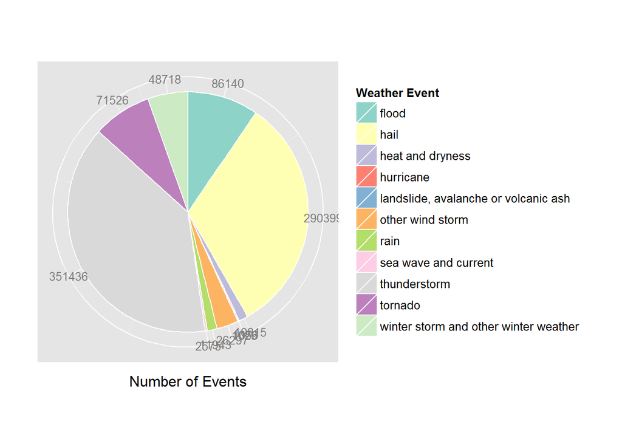

```r
p1
```

The 4 most frequent extreme weather event types are:

- Thunderstorm: 351436 events so 38.96% of total event number.
- Hail: 290399 events so 32.20% of total event number.
- Flood: 86140 events so 9.55% of total event number.
- Tornado: 71526 events so 7.93% of total event number.

The following figure is a panel plot with two pie plots. It is illustrating the Human consequences of each type of weather event in term of injuries and fatalities.

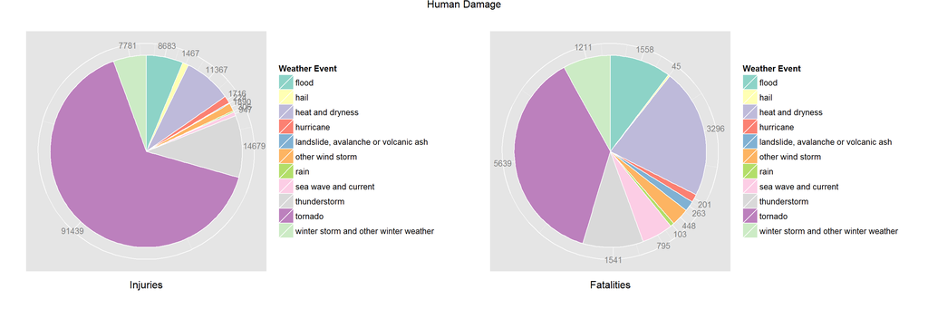

```r
phum <- grid.arrange(p2, p3, ncol = 2, main = "Human Damage")
```

The extreme weather events that lead to the most injuries are:

- Tornado: 91439 injuries so 65.08% of total number of injuries.
- Thunderstorm: 14679 injuries so 10.45% of total number of injuries.
- Heat and dryness: 11367 injuries so 8.09% of total number of injuries.
- Flood: 8683 injuries so 6.18% of total number of injuries.
- Winter storm and other winter weather: 7781 injuries so 5.54% of total number of injuries.

The extreme weather events that lead to the most fatalities are:

- Tornado:5639 fatalities so 37.34% of total number of fatalities.
- Heat and dryness: 3296 fatalities so 21.83% of total number of fatalities.
- Flood: 1558 fatalities so 10.32% of total number of fatalities.
- Thunderstorm: 1541 fatalities so 10.21% of total number of fatalities.
- Winter storm and other winter weather: 1211 fatalities so 8.02% of total number of fatalities.

The following figure is a panel plot with two pie plots. It is illustrating the economic consequences of each type of weather event in term of property and crop damages.

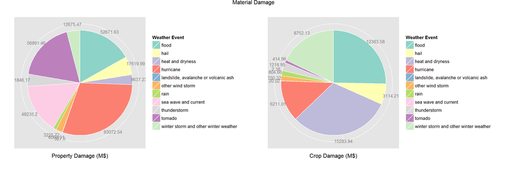

```r
pdmg <- grid.arrange(p4, p5, ncol = 2, main = "Material Damage")
```

The extreme weather events that lead to the most property damages are:

- Hurricane: 93072.5 M$ of property damages so 29.80% of the total number of property damages.
- Tornado: 56991.5 M$ of property damages so 18.24% of the total number of property damages.
- Flood: 52671.6 M$ of property damages so 16.86% of the total number of property damages.
- Sea wave and current: 48235.2 M$ of property damages so 15.44% of the total number of property damages.

The extreme weather events that lead to the most crop damages are:

- Heat and dryness: 15283.94 of crop damages so 31.22% of the total number of crop damages.
- Flood: 12383.58 of crop damages so 25.30% of the total number of crop damages.
- Winter storm and other winter weather: 8752.13 of crop damages so 17.88% of the total number of crop damages.
- Hurricane: 6211.01 of crop damages so 12.69% of the total number of crop damages.

### 3 Conclusions

Even though the Thunderstorms and Hails are the severe weather event the most frequent (respectively 38.96% and 32.20%), they are not the most harmful with the population health and they have not the greatest economic consequences.

Clearly the Tornados are the most harmful with the population health. Indeed they represent 65.08% of the injuries and 37.34% of the fatalities. Then Heat and dryness represent 8.09% of the injuries and 21.83% of the fatalities.

Economicaly speaking Hurricanes have the greatest consequences with 29.80% of the property damages and 12.69% of the crop damages. Then Floods represent 16.86% of the property damages and 25.30% of the crop damages. Tornados and Sea wave and current have also great consequences for property damages (18.24%, 15.44%).

Heat and dryness is the worst for crops,it represents 31.22% of the crop damages.